# R Notebook

# Libraries

```r
library(tidyverse)
library(modelr)
library(ggfortify)
library(GGally)
library(lubridate)
```

# Task brief

We’ve looked at a few different ways in which we can build models this week, including how to prepare them properly. This weekend we’ll build a multiple linear regression model on a dataset which will need some preparation. The data can be found in the data folder, along with a data dictionary

We want to investigate the avocado dataset, and, in particular, to model the AveragePrice of the avocados. Use the tools we’ve worked with this week in order to prepare your dataset and find appropriate predictors. Once you’ve built your model use the validation techniques discussed on Wednesday to evaluate it. Feel free to focus either on building an explanatory or a predictive model, or both if you are feeling energetic!

As part of the MVP we want you not to just run the code but also have a go at interpreting the results and write your thinking in comments in your script.

# Data exploration

```r
avocados <- read_csv("data/avocado.csv") %>% janitor::clean_names()
```

[output not shown]

## notes on PLU codes:

PLU codes are used to identify bulk produce and indicate information that could be related to price - e.g. conventionally grown avocados vs organically grown ones (organic tends to be more expensive). Other information included in these codes is: commodity, variety, growing methodology (e.g., organic), and the size.

```r
skimr::skim(avocados)
```

```
-- Data Summary ------------------------
                           Values
Name                       avocados
Number of rows             18249
Number of columns          14
_______________________
Column type frequency:
  character                2
  Date                     1
  numeric                  11
________________________
Group variables            None
```

|  | skim_variable | n_missing | complete_rate | min | max | empty | n_unique | whitespace |
| --- | --- | --- | --- | --- | --- | --- | --- | --- |
| 1 | type | 0 | 1 | 7 | 12 | 0 | 2 | 0 |
| 2 | region | 0 | 1 | 4 | 19 | 0 | 54 | 0 |

|  | skim_variable | n_missing | complete_rate | min | max | median | n_unique |
| --- | --- | --- | --- | --- | --- | --- | --- |
| 1 | date | 0 | 1 | 2015-01-04 | 2018-03-25 | 2016-08-14 | 169 |

|  | skim_variable | n_missing | complete_rate | mean | sd | p0 | p25 | p50 | p75 | p100 | hist |
| --- | --- | --- | --- | --- | --- | --- | --- | --- | --- | --- | --- |
| 1 | x1 | 0 | 1 | 2.423223e+01 | 1.548104e+01 | 0.00 | 10.00 | 24.00 | 38.00 | 52.00 |  |
| 2 | average_price | 0 | 1 | 1.405978e+00 | 4.026766e-01 | 0.44 | 1.10 | 1.37 | 1.66 | 3.25 |  |
| 3 | total_volume | 0 | 1 | 8.506440e+05 | 3.453545e+06 | 84.56 | 10838.58 | 107376.76 | 432962.29 | 62505646.52 |  |
| 4 | x4046 | 0 | 1 | 2.930084e+05 | 1.264989e+06 | 0.00 | 854.07 | 8645.30 | 111020.20 | 22743616.17 |  |
| 5 | x4225 | 0 | 1 | 2.951546e+05 | 1.204120e+06 | 0.00 | 3008.78 | 29061.02 | 150206.86 | 20470572.61 |  |
| 6 | x4770 | 0 | 1 | 2.283974e+04 | 1.074641e+05 | 0.00 | 0.00 | 184.99 | 6243.42 | 2546439.11 |  |
| 7 | total_bags | 0 | 1 | 2.396392e+05 | 9.862424e+05 | 0.00 | 5088.64 | 39743.83 | 110783.37 | 19373134.37 |  |
| 8 | small_bags | 0 | 1 | 1.821947e+05 | 7.461785e+05 | 0.00 | 2849.42 | 26362.82 | 83337.67 | 13384586.80 |  |
| 9 | large_bags | 0 | 1 | 5.433809e+04 | 2.439660e+05 | 0.00 | 127.47 | 2647.71 | 22029.25 | 5719096.61 |  |
| 10 | x_large_bags | 0 | 1 | 3.106427e+03 | 1.769289e+04 | 0.00 | 0.00 | 0.00 | 132.50 | 551693.65 |  |

[output cut: 1 more lines]

## Notes on dataset and potential new variables and cleaning steps

- The timespan of the data is more than 3 years, so it’s reasonable to think that the price will have increased. We might also expect the month to be useful to predicting price since avocados might be cheaper when they are in season (and there are more available). We should extract month from date since year is already recorded in the dataset and then drop date. We can then transform months into seasons to reduce the number of categories since 12 is a lot.

-We might want to make the PLU codes proportions of the total volume - this would potentially be more helpful than the number of each PLU code since the regions are very different sizes (e.g. one is the entirety of the US)

-We might want to make the bags proportions of total bags for the same reason as above.

-Let’s change type to a logical variable indicating whether or not the avocados were organic and then drop type

## Notes on region

- these are an assortment of regions, total US and major metropolitan areas

| region | n |
| --- | --- |
| Albany | 338 |
| Atlanta | 338 |
| BaltimoreWashington | 338 |
| Boise | 338 |
| Boston | 338 |
| BuffaloRochester | 338 |
| California | 338 |
| Charlotte | 338 |
| Chicago | 338 |
| CincinnatiDayton | 338 |

[output cut: 44 more lines]

Other than the ones below, the rest of the values in “region” are names of major metropolitan areas WestTexNewMexico West TotalUS Southeast SouthCentral SouthCarolina Plains NorthernNewEngland Northeast Midsouth GreatLakes

### Investigate region to see if it’s worth keeping in.

Based on the boxplots below, there do seem to be some differences between different regions (e.g. northeast and south central); however, creating a major metropolitan areas group doesn’t seem to be a good way of amalgamating the rest of the data since there are so many outliers. It would potentially be an idea to add these cities to their respective regions (e.g. “Portland” to “West”); however, this would mean a lot of hard coding to keep this variable.

Additionally, the dataset uses some regions that are difficult to discern the difference between (e.g. midsouth and southcentral). Some additional searching showed that there isn’t a consensus on how to divide the US into regions and the factor analysis that I found used county data to investigate socioeconomic differences in regions. Although this breakdown might be very useful to the analysis, we just don’t have that level of detail in this dataset. So, my decision is to drop region

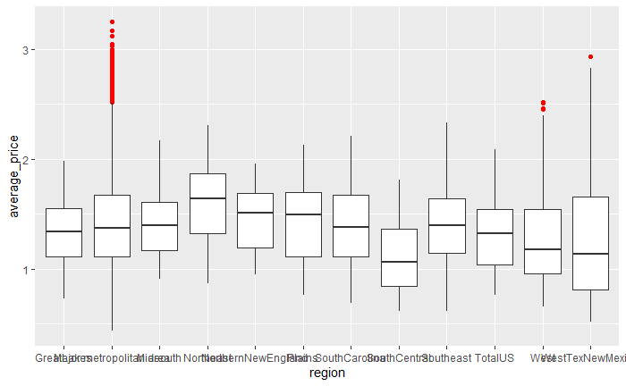

```r
avocados %>%
  mutate(region = if_else(region %in% c("WestTexNewMexico",
                                        "West",
                                        "TotalUS",
                                        "Southeast",
                                        "SouthCentral",
                                        "SouthCarolina",
                                        "Plains",
                                        "NorthernNewEngland",
                                        "Northeast",
                                        "Midsouth",
                                        "GreatLakes"), region,
                                        "Major metropolitan area")) %>%
  ggplot(aes(x = region,
         y = average_price)) +
  geom_boxplot(outlier.color = "red")
```

## Clean up variables and check for aliases

```r
avocados_tidy <- avocados %>%
  #clean up variables as described in notes above
  mutate(prop_4046 = x4046/total_volume,
         prop_4225 = x4225/total_volume,
         prop_4770 = x4770/total_volume,
         prop_small_bag = small_bags/total_bags,
         prop_large_bag = large_bags/total_bags,
         prop_xl_bag = x_large_bags/total_bags,
         month = lubridate::month(date, label = TRUE),
         season = case_when(
           month %in% c("Jan", "Feb", "Dec") ~ "Winter",
           month %in% c("Mar", "Apr", "May") ~ "Spring",
           month %in% c("Jun", "Jul", "Aug") ~ "Summer",
           TRUE ~ "Fall"
         ),
         is_organic = type == "organic") %>%
  #we don't need the bag or PLU data now that we've replaced with proportions and we no longer need type or date
  select(-c(x1, date, region, x4046, x4225, x4770, small_bags, large_bags,
            x_large_bags, type, month))
```

```r
#checking for aliased variables
alias(average_price ~ ., avocados_tidy)
```

```
Model :
average_price ~ total_volume + total_bags + year + prop_4046 +
    prop_4225 + prop_4770 + prop_small_bag + prop_large_bag +
    prop_xl_bag + season + is_organic
```

No aliased variables in the set.

# Create test/train sets

Using 80/20 proportion to split dataset into train/test

```r
n_data <- nrow(avocados_tidy)
test_index <- sample(1:n_data, size = n_data * 0.2)

test_avocados <- slice(avocados_tidy, test_index)
train_avocadoes <- slice(avocados_tidy, -test_index)
```

# Look at train dataset

```r
train_avocadoes %>% skimr::skim()
```

```
-- Data Summary ------------------------
                           Values
Name                       Piped data
Number of rows             14600
Number of columns          12
_______________________
Column type frequency:
  character                1
  logical                  1
  numeric                  10
________________________
Group variables            None
```

|  | skim_variable | n_missing | complete_rate | min | max | empty | n_unique | whitespace |
| --- | --- | --- | --- | --- | --- | --- | --- | --- |
| 1 | season | 0 | 1 | 4 | 6 | 0 | 4 | 0 |

|  | skim_variable | n_missing | complete_rate | mean | count |
| --- | --- | --- | --- | --- | --- |
| 1 | is_organic | 0 | 1 | 0.4992466 | FAL: 7311, TRU: 7289 |

|  | skim_variable | n_missing | complete_rate | mean | sd | p0 | p25 | p50 | p75 | p100 | hist |
| --- | --- | --- | --- | --- | --- | --- | --- | --- | --- | --- | --- |
| 1 | average_price | 0 | 1.0000000 | 1.406273e+00 | 4.039101e-01 | 0.44 | 1.100000e+00 | 1.370000e+00 | 1.660000e+00 | 3.250000e+00 |  |
| 2 | total_volume | 0 | 1.0000000 | 8.398842e+05 | 3.380113e+06 | 84.56 | 1.084711e+04 | 1.072484e+05 | 4.354251e+05 | 6.250565e+07 |  |
| 3 | total_bags | 0 | 1.0000000 | 2.371488e+05 | 9.652843e+05 | 0.00 | 5.007028e+03 | 4.001433e+04 | 1.110726e+05 | 1.937313e+07 |  |
| 4 | year | 0 | 1.0000000 | 2.016146e+03 | 9.394620e-01 | 2015.00 | 2.015000e+03 | 2.016000e+03 | 2.017000e+03 | 2.018000e+03 |  |
| 5 | prop_4046 | 0 | 1.0000000 | 2.247932e-01 | 2.140050e-01 | 0.00 | 3.251081e-02 | 1.585592e-01 | 3.779010e-01 | 9.725234e-01 |  |
| 6 | prop_4225 | 0 | 1.0000000 | 3.492167e-01 | 2.356293e-01 | 0.00 | 1.590909e-01 | 3.185426e-01 | 5.206678e-01 | 9.926278e-01 |  |
| 7 | prop_4770 | 0 | 1.0000000 | 1.930708e-02 | 4.207025e-02 | 0.00 | 0.000000e+00 | 1.487677e-03 | 1.896325e-02 | 4.487194e-01 |  |
| 8 | prop_small_bag | 9 | 0.9993836 | 7.514236e-01 | 2.846261e-01 | 0.00 | 5.860384e-01 | 8.737061e-01 | 9.873398e-01 | 1.000000e+00 |  |
| 9 | prop_large_bag | 9 | 0.9993836 | 2.410492e-01 | 2.850440e-01 | 0.00 | 9.466888e-03 | 1.138304e-01 | 4.036747e-01 | 1.000000e+00 |  |
| 10 | prop_xl_bag | 9 | 0.9993836 | 7.527241e-03 | 2.648843e-02 | 0.00 | 0.000000e+00 | 0.000000e+00 | 1.014878e-03 | 6.447668e-01 |  |

There’s only a few NAs, so we can probably impute them with the median.

```r
train_avocadoes <- train_avocadoes %>%
  mutate(across(prop_small_bag:prop_xl_bag,
                ~coalesce(.x, median(.x, na.rm = TRUE))))
```

#Look at ggpairs

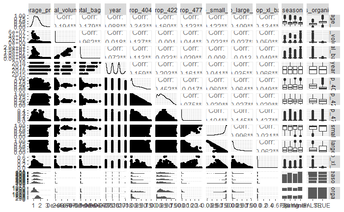

```r
ggpairs(train_avocadoes, progress = FALSE)
```

prop_4046 and is_organic are both looking like the most promising predictors at this point.

# First predictor

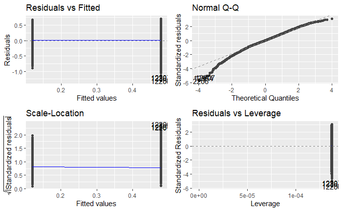

```r
#Changed to log of price after looking at the autoplot
mod_1a <- lm(log(average_price) ~ is_organic, train_avocadoes)

autoplot(mod_1a)
```

```r
summary(mod_1a)
```

```
Call:
lm(formula = log(average_price) ~ is_organic, data = train_avocadoes)

Residuals:
     Min       1Q   Median       3Q      Max
-1.30019 -0.13562  0.00321  0.14996  0.69944

Coefficients:
               Estimate Std. Error t value Pr(>|t|)
(Intercept)    0.120067   0.002675   44.89   <2e-16 ***
is_organicTRUE 0.359145   0.003786   94.86   <2e-16 ***
---
Signif. codes:  0 ‘***’ 0.001 ‘**’ 0.01 ‘*’ 0.05 ‘.’ 0.1 ‘ ’ 1

Residual standard error: 0.2287 on 14598 degrees of freedom
Multiple R-squared:  0.3814,    Adjusted R-squared:  0.3813
F-statistic:  8999 on 1 and 14598 DF,  p-value: < 2.2e-16
```

```r
bptest(mod_1a)
```

```
    studentized Breusch-Pagan test

data:  mod_1a
BP = 1.201, df = 1, p-value = 0.2731
```

## Interpretation of mod_1a

Residuals vs fitted looks okay (although it’s difficult to tell because is_organic is a binary variable), the QQ plot looks non-normal, scale location has a slight downward trend, but nothing too awful. However, there are only two fitted values here (because it’s a binary variable), so it’s quite difficult to tell anything from this plot as well.

- R^2 is 0.38, so overall, whether or not an avocado is organic can explain 38% of the variance in average price.
- If an avocado is organic, on average, we can expect to see an average log price about $0.35 higher when compared with non-organic avocados. This is around a 42% increase in average price for organic avocados vs non-organic.

```r
(exp(0.35) - 1) * 100
```

```
[1] 41.90675
```

- The p-value was significant at the 0.1% level, meaning that we can reject the null hypothesis that there is no significant difference between organic and non-organic avocados. We would only see this extreme of a difference in price by chance around 0.1% of the time.

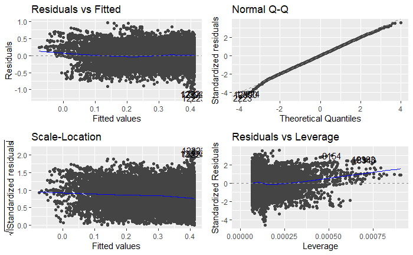

```r
mod_1b <- lm(log(average_price) ~ prop_4046, train_avocadoes)

autoplot(mod_1b)
```

```r
summary(mod_1b)
```

```
Call:
lm(formula = log(average_price) ~ prop_4046, data = train_avocadoes)

Residuals:
     Min       1Q   Median       3Q      Max
-1.23133 -0.18454  0.00216  0.18320  0.95890

Coefficients:
             Estimate Std. Error t value Pr(>|t|)
(Intercept)  0.412100   0.003241  127.16   <2e-16 ***
prop_4046   -0.500611   0.010442  -47.94   <2e-16 ***
---
Signif. codes:  0 ‘***’ 0.001 ‘**’ 0.01 ‘*’ 0.05 ‘.’ 0.1 ‘ ’ 1

Residual standard error: 0.27 on 14598 degrees of freedom
Multiple R-squared:  0.136, Adjusted R-squared:  0.136
F-statistic:  2298 on 1 and 14598 DF,  p-value: < 2.2e-16
```

Whether or not an avocado is organic is the best predictor - which makes sense in a real context as well since we would generally expect organic produce to be more expensive than conventional produce.

## Check residue from mod_1a

```r
avocado_resid <- train_avocadoes %>%
  add_residuals(mod_1a) %>%
  select(-average_price)

avocado_resid %>%
  ggpairs(aes(colour = is_organic, alpha = 0.5), progress = FALSE)
```

[output not shown]

## Notes

Prop 4225 has the highest correlation with the residuals, but there also looks like there could be differences by season.

# Second predictor

Let’s try prop 4225 and season.

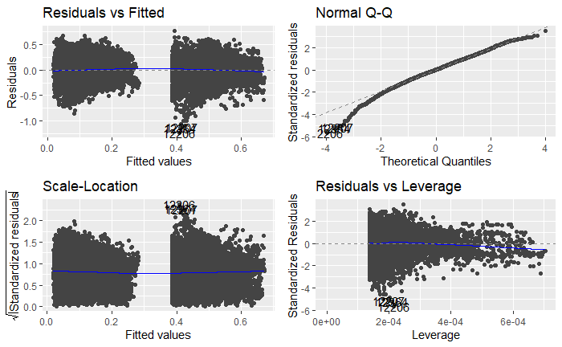

```r
mod_2a <- lm(log(average_price) ~ is_organic + prop_4225,
             data = train_avocadoes)

autoplot(mod_2a)
```

```r
summary(mod_2a)
```

```
Call:
lm(formula = log(average_price) ~ is_organic + prop_4225, data = train_avocadoes)

Residuals:
     Min       1Q   Median       3Q      Max
-1.22881 -0.13291  0.00317  0.14922  0.75937

Coefficients:
               Estimate Std. Error t value Pr(>|t|)
(Intercept)    0.013436   0.003854   3.486 0.000492 ***
is_organicTRUE 0.373097   0.003640 102.501  < 2e-16 ***
prop_4225      0.287200   0.007766  36.980  < 2e-16 ***
---
Signif. codes:  0 ‘***’ 0.001 ‘**’ 0.01 ‘*’ 0.05 ‘.’ 0.1 ‘ ’ 1

Residual standard error: 0.2187 on 14597 degrees of freedom
Multiple R-squared:  0.4343,    Adjusted R-squared:  0.4343
F-statistic:  5604 on 2 and 14597 DF,  p-value: < 2.2e-16
```

```r
bptest(mod_2a)
```

```
    studentized Breusch-Pagan test

data:  mod_2a
BP = 60.961, df = 2, p-value = 5.786e-14
```

## Interpretation of mod_2a

The autoplots don’t look too terrible, but it’s difficult to tell because there’s a big gap in the scale-location plot and the residuals vs fitted plot. This is surely because of the is_organic variable. It does look like there is some sort of pattern in the scale-location plot now and the bp test was significant, indicating that we haven’t satisfied the assumption of homoskedasticity.

```r
#equation to find the percent increase(or decrease) in response for every one unit increase in independent variable
(exp(0.28) - 1) * 100
```

```
[1] 32.31298
```

What does this mean?  
It would be good if we knew what the difference was between the different PLU codes, but the PLU description says that this could indicate differences in variety and size, so perhaps avocados with PLU 4225 are bigger or of a more attractive variety than the other PLU codes. This is just a guess, we can’t know for sure unless we had data about the qualitative differences between avocados with different PLU codes.

```r
mod_2b <- lm(log(average_price) ~ is_organic + season,
             data = train_avocadoes)

autoplot(mod_2b)

summary(mod_2b)

bptest(mod_2b)
```

[output not shown]

Prop 4225 performs better in the model than season

## Check the residue from mod_2a

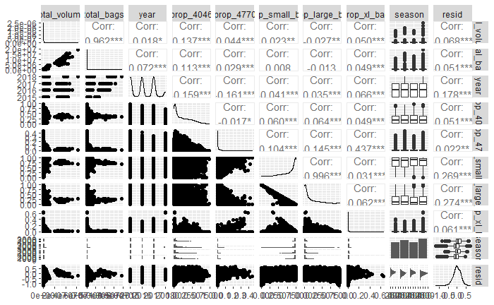

```r
avocado_resid <- train_avocadoes %>%
  add_residuals(mod_2a) %>%
  select(-average_price, -is_organic, -prop_4225)

avocado_resid %>%
  ggpairs(progress = FALSE)
```

## Notes

Prop_large_bag is looking like the strongest correlation now, although it still looks like there is a slight difference in season

# Third predictor

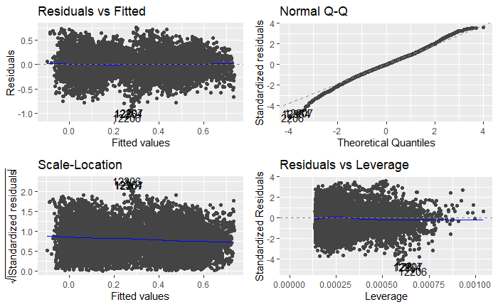

```r
mod_3a <- lm(log(average_price) ~ is_organic + prop_4225 + prop_large_bag,
             data = train_avocadoes)

autoplot(mod_3a)
```

```r
summary(mod_3a)
```

```
Call:
lm(formula = log(average_price) ~ is_organic + prop_4225 + prop_large_bag,
    data = train_avocadoes)

Residuals:
     Min       1Q   Median       3Q      Max
-1.07862 -0.13072 -0.00217  0.13718  0.75364

Coefficients:
                Estimate Std. Error t value Pr(>|t|)
(Intercept)     0.052637   0.003890   13.53   <2e-16 ***
is_organicTRUE  0.389370   0.003539  110.02   <2e-16 ***
prop_4225       0.296402   0.007486   39.60   <2e-16 ***
prop_large_bag -0.208592   0.006184  -33.73   <2e-16 ***
---
Signif. codes:  0 ‘***’ 0.001 ‘**’ 0.01 ‘*’ 0.05 ‘.’ 0.1 ‘ ’ 1

Residual standard error: 0.2107 on 14596 degrees of freedom
Multiple R-squared:  0.4753,    Adjusted R-squared:  0.4751
F-statistic:  4407 on 3 and 14596 DF,  p-value: < 2.2e-16
```

```r
bptest(mod_3a)
```

```
    studentized Breusch-Pagan test

data:  mod_3a
BP = 617.72, df = 3, p-value < 2.2e-16
```

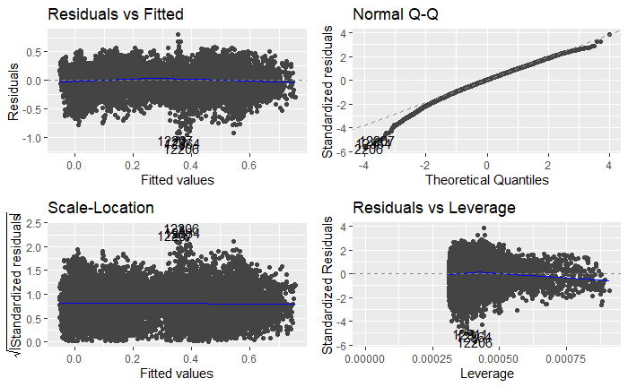

```r
mod_3b <- lm(log(average_price) ~ is_organic + prop_4225 + season,
             data = train_avocadoes)

autoplot(mod_3b)
```

```r
summary(mod_3b)
```

```
Call:
lm(formula = log(average_price) ~ is_organic + prop_4225 + season,
    data = train_avocadoes)

Residuals:
     Min       1Q   Median       3Q      Max
-1.18798 -0.12798  0.01052  0.14144  0.80001

Coefficients:
                Estimate Std. Error t value Pr(>|t|)
(Intercept)     0.107433   0.004853  22.138   <2e-16 ***
is_organicTRUE  0.372366   0.003474 107.192   <2e-16 ***
prop_4225       0.283287   0.007414  38.211   <2e-16 ***
seasonSpring   -0.133803   0.004939 -27.089   <2e-16 ***
seasonSummer   -0.049970   0.005091  -9.816   <2e-16 ***
seasonWinter   -0.164673   0.004869 -33.819   <2e-16 ***
---
Signif. codes:  0 ‘***’ 0.001 ‘**’ 0.01 ‘*’ 0.05 ‘.’ 0.1 ‘ ’ 1

Residual standard error: 0.2087 on 14594 degrees of freedom
Multiple R-squared:  0.4849,    Adjusted R-squared:  0.4848
F-statistic:  2748 on 5 and 14594 DF,  p-value: < 2.2e-16
```

```r
bptest(mod_3b)
```

```
    studentized Breusch-Pagan test

data:  mod_3b
BP = 150.68, df = 5, p-value < 2.2e-16
```

Mod_3b is better

## Interpretation of mod_3b

```r
#equation to find the percent increase(or decrease) in response for every one unit increase in independent variable
(exp(0.16) - 1) * 100
```

```
[1] 17.35109
```

What does this mean? - It’s a little unclear why we would predict lower prices for avocados in the winter when compared with fall. To be fair, these prices are not that much lower, even though there is a statistically significant difference. When checking online, it seems like since Mexican avocados started to be imported into the US, there’s not really a set season for avocados since they grow all year round in Mexico. Does this potentially mean that we’re getting to the end of the variables that make sense in predicting average price of avocados?

## Check the residue from mod_3b

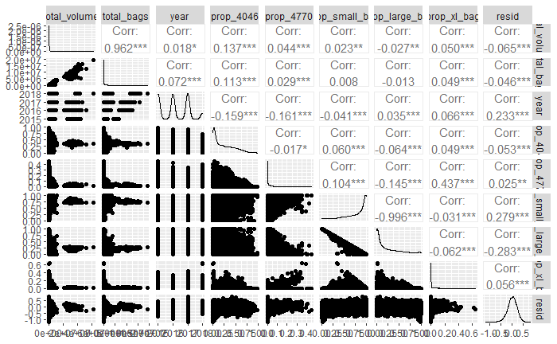

```r
avocado_resid <- train_avocadoes %>%
  add_residuals(mod_3b) %>%
  select(-average_price, -is_organic, -prop_4225, -season)

avocado_resid %>%
  ggpairs(progress = FALSE)
```

## Notes

-The most promising predictor here is prop_large_bag, although year also looks promising.

# Fourth predictor

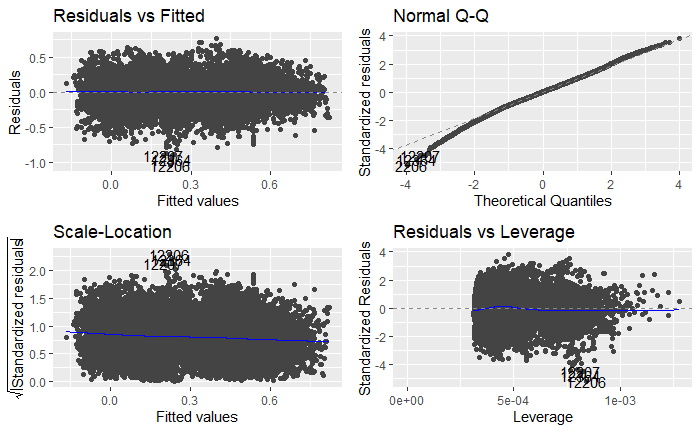

```r
#model with prop_large_bag
mod_4a <- lm(log(average_price) ~ is_organic + prop_4225 + season + prop_large_bag,
             data = train_avocadoes)

autoplot(mod_4a)
```

```r
summary(mod_4a)
```

```
Call:
lm(formula = log(average_price) ~ is_organic + prop_4225 + season +
    prop_large_bag, data = train_avocadoes)

Residuals:
     Min       1Q   Median       3Q      Max
-1.04225 -0.12520  0.00427  0.12930  0.75975

Coefficients:
                Estimate Std. Error t value Pr(>|t|)
(Intercept)     0.146283   0.004793   30.52   <2e-16 ***
is_organicTRUE  0.388413   0.003369  115.29   <2e-16 ***
prop_4225       0.292431   0.007127   41.03   <2e-16 ***
seasonSpring   -0.131747   0.004746  -27.76   <2e-16 ***
seasonSummer   -0.053261   0.004892  -10.89   <2e-16 ***
seasonWinter   -0.164756   0.004678  -35.22   <2e-16 ***
prop_large_bag -0.205581   0.005889  -34.91   <2e-16 ***
---
Signif. codes:  0 ‘***’ 0.001 ‘**’ 0.01 ‘*’ 0.05 ‘.’ 0.1 ‘ ’ 1

Residual standard error: 0.2005 on 14593 degrees of freedom
Multiple R-squared:  0.5246,    Adjusted R-squared:  0.5244
F-statistic:  2684 on 6 and 14593 DF,  p-value: < 2.2e-16
```

```r
bptest(mod_4a)
```

```
    studentized Breusch-Pagan test

data:  mod_4a
BP = 672.22, df = 6, p-value < 2.2e-16
```

## Interpretation of mod_4a

-We are continuing to see a downward trend in the the scale location plot and it looks a bit worse here than the last model. The bp test was significant, indicating that we haven’t satisfied the assumption of homoskedasticity.

```r
#equation to find the percent increase(or decrease) in response for every one unit increase in independent variable
(exp(0.21) - 1) * 100
```

```
[1] 23.36781
```

- What does this mean - this makes sense from a real world perspective because when you buy a larger bag, the unit price of the produce or product sold in the bag is usually less because you are buying in bulk. Therefore, we would expect that as the proportion of large bags sold increases, the unit price would decrease.

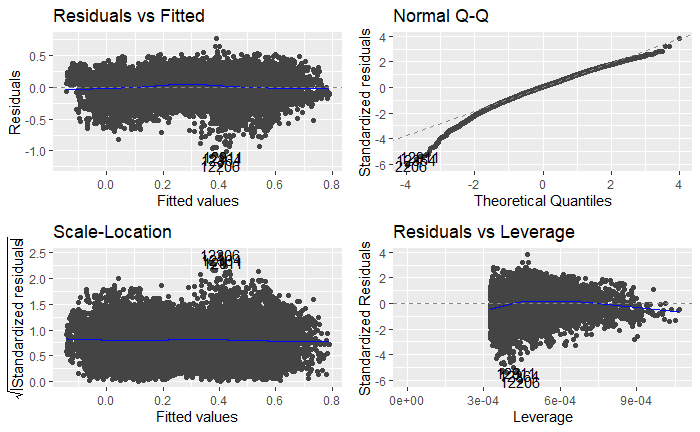

```r
mod_4b <- lm(log(average_price) ~ is_organic + prop_4225 + season + year,
             data = train_avocadoes)

autoplot(mod_4b)
```

```r
summary(mod_4b)
```

```
Call:
lm(formula = log(average_price) ~ is_organic + prop_4225 + season +
    year, data = train_avocadoes)

Residuals:
     Min       1Q   Median       3Q      Max
-1.22482 -0.12354  0.01052  0.13516  0.76530

Coefficients:
                 Estimate Std. Error t value Pr(>|t|)
(Intercept)    -1.162e+02  3.718e+00  -31.26   <2e-16 ***
is_organicTRUE  3.742e-01  3.363e-03  111.25   <2e-16 ***
prop_4225       3.287e-01  7.323e-03   44.89   <2e-16 ***
seasonSpring   -1.434e-01  4.792e-03  -29.93   <2e-16 ***
seasonSummer   -5.099e-02  4.928e-03  -10.35   <2e-16 ***
seasonWinter   -1.868e-01  4.767e-03  -39.19   <2e-16 ***
year            5.769e-02  1.844e-03   31.29   <2e-16 ***
---
Signif. codes:  0 ‘***’ 0.001 ‘**’ 0.01 ‘*’ 0.05 ‘.’ 0.1 ‘ ’ 1

Residual standard error: 0.2021 on 14593 degrees of freedom
Multiple R-squared:  0.5173,    Adjusted R-squared:  0.5171
F-statistic:  2607 on 6 and 14593 DF,  p-value: < 2.2e-16
```

```r
bptest(mod_4b)
```

```
    studentized Breusch-Pagan test

data:  mod_4b
BP = 311.72, df = 6, p-value < 2.2e-16
```

Prop large bag is a better model.

## Check residue from mod_4a

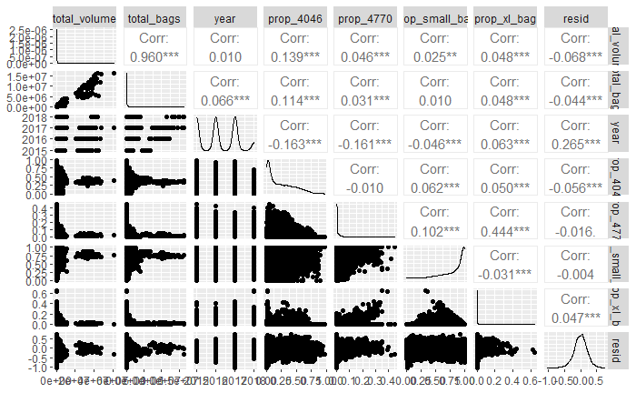

```r
avocado_resid <- train_avocadoes %>%
  add_residuals(mod_4a) %>%
  select(-average_price, -is_organic, -prop_4225, -season, - prop_large_bag)

avocado_resid %>%
  ggpairs(progress = FALSE)
```

## Notes

It looks like it might be useful to add year as a fifth predictor because its correlation with the residuals is comparatively high, while all the others have reduced significantly.

# Fifth predictor

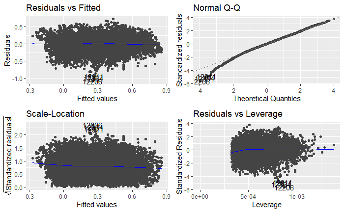

```r
#model with year
mod_5a <- lm(log(average_price) ~ is_organic + prop_4225 + season +
               prop_large_bag + year,
             data = train_avocadoes)

autoplot(mod_5a)
```

```r
summary(mod_5a)
```

```
Call:
lm(formula = log(average_price) ~ is_organic + prop_4225 + season +
    prop_large_bag + year, data = train_avocadoes)

Residuals:
     Min       1Q   Median       3Q      Max
-1.07461 -0.11824  0.00376  0.12861  0.72137

Coefficients:
                 Estimate Std. Error t value Pr(>|t|)
(Intercept)    -1.224e+02  3.551e+00  -34.48   <2e-16 ***
is_organicTRUE  3.910e-01  3.240e-03  120.68   <2e-16 ***
prop_4225       3.407e-01  6.995e-03   48.71   <2e-16 ***
seasonSpring   -1.418e-01  4.573e-03  -31.01   <2e-16 ***
seasonSummer   -5.449e-02  4.704e-03  -11.58   <2e-16 ***
seasonWinter   -1.881e-01  4.549e-03  -41.35   <2e-16 ***
prop_large_bag -2.147e-01  5.669e-03  -37.88   <2e-16 ***
year            6.080e-02  1.761e-03   34.52   <2e-16 ***
---
Signif. codes:  0 ‘***’ 0.001 ‘**’ 0.01 ‘*’ 0.05 ‘.’ 0.1 ‘ ’ 1

Residual standard error: 0.1928 on 14592 degrees of freedom
Multiple R-squared:  0.5605,    Adjusted R-squared:  0.5603
F-statistic:  2659 on 7 and 14592 DF,  p-value: < 2.2e-16
```

```r
bptest(mod_5a)
```

```
    studentized Breusch-Pagan test

data:  mod_5a
BP = 760.58, df = 7, p-value < 2.2e-16
```

## Interpretation of mod_5a

-We are continuing to see a downward trend in the the scale location plot and it looks a bit worse here than the last model again. The bp test was also significant, indicating that we haven’t satisfied the assumption of homoskedasticity.

- We can see that the R^2 value has increased and the adjusted R^2 hasn’t penalised us too much for adding another variable to the model. The model can now explain around 56% of the variance in log average price We should also try comparing the BIC of the last two models. -The p value for year is significant at the 0.01% level, meaning that we can reject the null hypothesis that there is no relationship between the log average price of an avocado and the year.
- The coefficient for year is 0.061, meaning that for each 1 year increase, we can expect to see, on average, a $0.06 increase in the log average price of a single avocado. This is around a 6% increase in average price.

```r
#equation to find the percent increase(or decrease) in response for every one unit increase in independent variable
(exp(0.06) - 1) * 100
```

```
[1] 6.183655
```

- What does this mean? - This makes sense using real world logic, as generally we would expect the cost of produce to increase over time.

## Compare BIC for mod_4a and mod_5a

```r
BIC(mod_3b)
```

```
[1] -4253.658
```

```r
BIC(mod_4a)
```

```
[1] -5414.997
```

```r
BIC(mod_5a)
```

```
[1] -6551.436
```